# Risk Factor Analysis

## Outcome Variable

**Outcome Variable:** pers_wast

## Predictor Variables

**Intervention Variable:** fhtcm

**Adjustment Set:**

- arm
- W_mage
- W_fage
- meducyrs
- feducyrs
- W_mhtcm
- W_mwtkg
- W_mbmi
- single
- delta_W_mage
- delta_W_fage
- delta_meducyrs
- delta_feducyrs
- delta_W_mhtcm
- delta_W_mwtkg
- delta_W_mbmi
- delta_single

## Stratifying Variables

The analysis was stratified on these variable(s):

- agecat
- studyid
- country

## Data Summary

| agecat | studyid | country | fhtcm | pers_wast | n_cell | n |
| --- | --- | --- | --- | --- | --- | --- |
| 0-24 months | ki1000304b-SAS-CompFeed | INDIA | >=167 cm | 0 | 358 | 824 |
| 0-24 months | ki1000304b-SAS-CompFeed | INDIA | >=167 cm | 1 | 27 | 824 |
| 0-24 months | ki1000304b-SAS-CompFeed | INDIA | <162 cm | 0 | 179 | 824 |
| 0-24 months | ki1000304b-SAS-CompFeed | INDIA | <162 cm | 1 | 15 | 824 |
| 0-24 months | ki1000304b-SAS-CompFeed | INDIA | [162-167) cm | 0 | 222 | 824 |
| 0-24 months | ki1000304b-SAS-CompFeed | INDIA | [162-167) cm | 1 | 23 | 824 |
| 0-24 months | ki1000304b-SAS-FoodSuppl | INDIA | >=167 cm | 0 | 89 | 370 |
| 0-24 months | ki1000304b-SAS-FoodSuppl | INDIA | >=167 cm | 1 | 11 | 370 |
| 0-24 months | ki1000304b-SAS-FoodSuppl | INDIA | <162 cm | 0 | 118 | 370 |
| 0-24 months | ki1000304b-SAS-FoodSuppl | INDIA | <162 cm | 1 | 34 | 370 |
| 0-24 months | ki1000304b-SAS-FoodSuppl | INDIA | [162-167) cm | 0 | 100 | 370 |
| 0-24 months | ki1000304b-SAS-FoodSuppl | INDIA | [162-167) cm | 1 | 18 | 370 |
| 0-24 months | ki1101329-Keneba | GAMBIA | >=167 cm | 0 | 1047 | 1717 |
| 0-24 months | ki1101329-Keneba | GAMBIA | >=167 cm | 1 | 58 | 1717 |
| 0-24 months | ki1101329-Keneba | GAMBIA | <162 cm | 0 | 113 | 1717 |
| 0-24 months | ki1101329-Keneba | GAMBIA | <162 cm | 1 | 11 | 1717 |
| 0-24 months | ki1101329-Keneba | GAMBIA | [162-167) cm | 0 | 465 | 1717 |
| 0-24 months | ki1101329-Keneba | GAMBIA | [162-167) cm | 1 | 23 | 1717 |
| 0-24 months | ki1119695-PROBIT | BELARUS | >=167 cm | 0 | 11639 | 12524 |
| 0-24 months | ki1119695-PROBIT | BELARUS | >=167 cm | 1 | 93 | 12524 |
| 0-24 months | ki1119695-PROBIT | BELARUS | <162 cm | 0 | 166 | 12524 |
| 0-24 months | ki1119695-PROBIT | BELARUS | <162 cm | 1 | 2 | 12524 |
| 0-24 months | ki1119695-PROBIT | BELARUS | [162-167) cm | 0 | 621 | 12524 |
| 0-24 months | ki1119695-PROBIT | BELARUS | [162-167) cm | 1 | 3 | 12524 |
| 0-24 months | ki1135781-COHORTS | GUATEMALA | >=167 cm | 0 | 55 | 424 |
| 0-24 months | ki1135781-COHORTS | GUATEMALA | >=167 cm | 1 | 1 | 424 |
| 0-24 months | ki1135781-COHORTS | GUATEMALA | <162 cm | 0 | 237 | 424 |
| 0-24 months | ki1135781-COHORTS | GUATEMALA | <162 cm | 1 | 12 | 424 |
| 0-24 months | ki1135781-COHORTS | GUATEMALA | [162-167) cm | 0 | 116 | 424 |
| 0-24 months | ki1135781-COHORTS | GUATEMALA | [162-167) cm | 1 | 3 | 424 |
| 0-6 months | ki1101329-Keneba | GAMBIA | >=167 cm | 0 | 927 | 1481 |
| 0-6 months | ki1101329-Keneba | GAMBIA | >=167 cm | 1 | 25 | 1481 |
| 0-6 months | ki1101329-Keneba | GAMBIA | <162 cm | 0 | 107 | 1481 |
| 0-6 months | ki1101329-Keneba | GAMBIA | <162 cm | 1 | 3 | 1481 |
| 0-6 months | ki1101329-Keneba | GAMBIA | [162-167) cm | 0 | 410 | 1481 |
| 0-6 months | ki1101329-Keneba | GAMBIA | [162-167) cm | 1 | 9 | 1481 |
| 0-6 months | ki1119695-PROBIT | BELARUS | >=167 cm | 0 | 10294 | 12014 |
| 0-6 months | ki1119695-PROBIT | BELARUS | >=167 cm | 1 | 962 | 12014 |
| 0-6 months | ki1119695-PROBIT | BELARUS | <162 cm | 0 | 145 | 12014 |
| 0-6 months | ki1119695-PROBIT | BELARUS | <162 cm | 1 | 16 | 12014 |
| 0-6 months | ki1119695-PROBIT | BELARUS | [162-167) cm | 0 | 547 | 12014 |
| 0-6 months | ki1119695-PROBIT | BELARUS | [162-167) cm | 1 | 50 | 12014 |
| 6-24 months | ki1000304b-SAS-CompFeed | INDIA | >=167 cm | 0 | 358 | 824 |
| 6-24 months | ki1000304b-SAS-CompFeed | INDIA | >=167 cm | 1 | 27 | 824 |
| 6-24 months | ki1000304b-SAS-CompFeed | INDIA | <162 cm | 0 | 179 | 824 |
| 6-24 months | ki1000304b-SAS-CompFeed | INDIA | <162 cm | 1 | 15 | 824 |
| 6-24 months | ki1000304b-SAS-CompFeed | INDIA | [162-167) cm | 0 | 222 | 824 |
| 6-24 months | ki1000304b-SAS-CompFeed | INDIA | [162-167) cm | 1 | 23 | 824 |
| 6-24 months | ki1000304b-SAS-FoodSuppl | INDIA | >=167 cm | 0 | 89 | 370 |
| 6-24 months | ki1000304b-SAS-FoodSuppl | INDIA | >=167 cm | 1 | 11 | 370 |
| 6-24 months | ki1000304b-SAS-FoodSuppl | INDIA | <162 cm | 0 | 118 | 370 |
| 6-24 months | ki1000304b-SAS-FoodSuppl | INDIA | <162 cm | 1 | 34 | 370 |
| 6-24 months | ki1000304b-SAS-FoodSuppl | INDIA | [162-167) cm | 0 | 100 | 370 |
| 6-24 months | ki1000304b-SAS-FoodSuppl | INDIA | [162-167) cm | 1 | 18 | 370 |
| 6-24 months | ki1101329-Keneba | GAMBIA | >=167 cm | 0 | 1047 | 1717 |
| 6-24 months | ki1101329-Keneba | GAMBIA | >=167 cm | 1 | 58 | 1717 |
| 6-24 months | ki1101329-Keneba | GAMBIA | <162 cm | 0 | 113 | 1717 |
| 6-24 months | ki1101329-Keneba | GAMBIA | <162 cm | 1 | 11 | 1717 |
| 6-24 months | ki1101329-Keneba | GAMBIA | [162-167) cm | 0 | 465 | 1717 |
| 6-24 months | ki1101329-Keneba | GAMBIA | [162-167) cm | 1 | 23 | 1717 |
| 6-24 months | ki1119695-PROBIT | BELARUS | >=167 cm | 0 | 11639 | 12524 |
| 6-24 months | ki1119695-PROBIT | BELARUS | >=167 cm | 1 | 93 | 12524 |
| 6-24 months | ki1119695-PROBIT | BELARUS | <162 cm | 0 | 166 | 12524 |
| 6-24 months | ki1119695-PROBIT | BELARUS | <162 cm | 1 | 2 | 12524 |
| 6-24 months | ki1119695-PROBIT | BELARUS | [162-167) cm | 0 | 621 | 12524 |
| 6-24 months | ki1119695-PROBIT | BELARUS | [162-167) cm | 1 | 3 | 12524 |
| 6-24 months | ki1135781-COHORTS | GUATEMALA | >=167 cm | 0 | 55 | 424 |
| 6-24 months | ki1135781-COHORTS | GUATEMALA | >=167 cm | 1 | 1 | 424 |
| 6-24 months | ki1135781-COHORTS | GUATEMALA | <162 cm | 0 | 237 | 424 |
| 6-24 months | ki1135781-COHORTS | GUATEMALA | <162 cm | 1 | 12 | 424 |
| 6-24 months | ki1135781-COHORTS | GUATEMALA | [162-167) cm | 0 | 116 | 424 |
| 6-24 months | ki1135781-COHORTS | GUATEMALA | [162-167) cm | 1 | 3 | 424 |

The following strata were considered:

- agecat: 0-24 months, studyid: ki1000304b-SAS-CompFeed, country: INDIA
- agecat: 0-24 months, studyid: ki1000304b-SAS-FoodSuppl, country: INDIA
- agecat: 0-24 months, studyid: ki1101329-Keneba, country: GAMBIA
- agecat: 0-24 months, studyid: ki1119695-PROBIT, country: BELARUS
- agecat: 0-24 months, studyid: ki1135781-COHORTS, country: GUATEMALA
- agecat: 0-6 months, studyid: ki1101329-Keneba, country: GAMBIA
- agecat: 0-6 months, studyid: ki1119695-PROBIT, country: BELARUS
- agecat: 6-24 months, studyid: ki1000304b-SAS-CompFeed, country: INDIA
- agecat: 6-24 months, studyid: ki1000304b-SAS-FoodSuppl, country: INDIA
- agecat: 6-24 months, studyid: ki1101329-Keneba, country: GAMBIA
- agecat: 6-24 months, studyid: ki1119695-PROBIT, country: BELARUS
- agecat: 6-24 months, studyid: ki1135781-COHORTS, country: GUATEMALA

### Dropped Strata

Some strata were dropped due to rare outcomes:

- agecat: 0-24 months, studyid: ki1119695-PROBIT, country: BELARUS
- agecat: 0-24 months, studyid: ki1135781-COHORTS, country: GUATEMALA
- agecat: 0-6 months, studyid: ki1101329-Keneba, country: GAMBIA
- agecat: 6-24 months, studyid: ki1119695-PROBIT, country: BELARUS
- agecat: 6-24 months, studyid: ki1135781-COHORTS, country: GUATEMALA

## Methods Detail

We’re interested in the causal parameters $E[Y_a]$ for all values of $a \in \mathcal{A}$. These parameters represent the mean outcome if, possibly contrary to fact, we intervened to set all units to have $A=a$. Under the randomization and positivity assumptions, these are identified by the statistical parameters $\psi_a=E_W[E_{Y|A,W}(Y|A=a,W)]$. In addition, we’re interested in the mean of $Y$, $E[Y]$ under no intervention (the observed mean). We will estimate these parameters by using SuperLearner to fit the relevant likelihood factors – $E_{Y|A,W}(Y|A=a,W)$ and $p(A=a|W)$, and then updating our likelihood fit using a joint TMLE.

For unadjusted analyses ($W=\{\}$), initial likelihoods were estimated using Lrnr_glm to estimate the simple $E(Y|A)$ and Lrnr_mean to estimate $p(A)$. For adjusted analyses, a small library containing Lrnr_glmnet, Lrnr_xgboost, and Lrnr_mean was used.

Having estimated these parameters, we will then use the delta method to estimate relative risks and attributable risks relative to a prespecified baseline level of $A$.

# Results Detail

## Results Plots

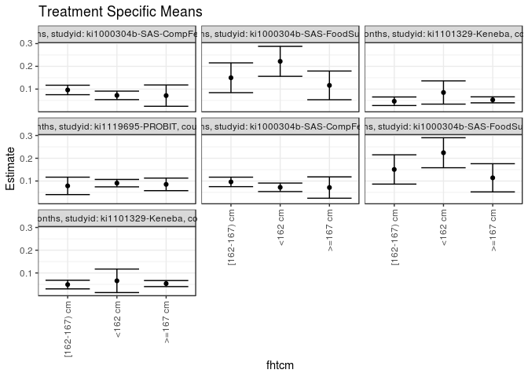

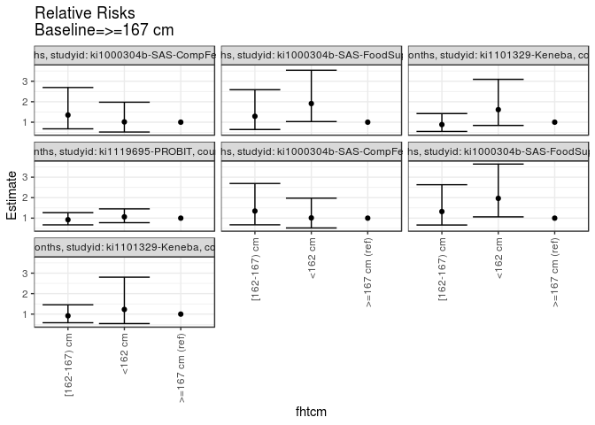

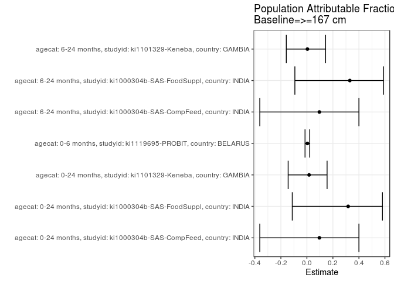

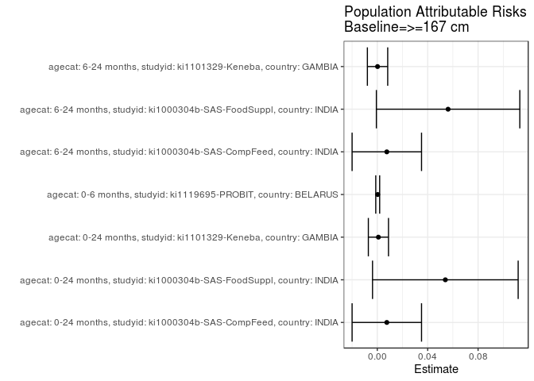

## Results Table

### Parameter: TSM

| agecat | studyid | country | intervention_level | baseline_level | estimate | ci_lower | ci_upper |
| --- | --- | --- | --- | --- | --- | --- | --- |
| 0-24 months | ki1000304b-SAS-CompFeed | INDIA | >=167 cm | NA | 0.0713165 | 0.0244665 | 0.1181664 |
| 0-24 months | ki1000304b-SAS-CompFeed | INDIA | <162 cm | NA | 0.0722774 | 0.0536597 | 0.0908952 |
| 0-24 months | ki1000304b-SAS-CompFeed | INDIA | [162-167) cm | NA | 0.0961379 | 0.0752814 | 0.1169944 |
| 0-24 months | ki1000304b-SAS-FoodSuppl | INDIA | >=167 cm | NA | 0.1162529 | 0.0532243 | 0.1792814 |
| 0-24 months | ki1000304b-SAS-FoodSuppl | INDIA | <162 cm | NA | 0.2219404 | 0.1560414 | 0.2878395 |
| 0-24 months | ki1000304b-SAS-FoodSuppl | INDIA | [162-167) cm | NA | 0.1497596 | 0.0842527 | 0.2152666 |
| 0-24 months | ki1101329-Keneba | GAMBIA | >=167 cm | NA | 0.0526751 | 0.0395294 | 0.0658209 |
| 0-24 months | ki1101329-Keneba | GAMBIA | <162 cm | NA | 0.0849263 | 0.0338388 | 0.1360138 |
| 0-24 months | ki1101329-Keneba | GAMBIA | [162-167) cm | NA | 0.0464841 | 0.0276422 | 0.0653261 |
| 0-6 months | ki1119695-PROBIT | BELARUS | >=167 cm | NA | 0.0852283 | 0.0576901 | 0.1127665 |
| 0-6 months | ki1119695-PROBIT | BELARUS | <162 cm | NA | 0.0906367 | 0.0743590 | 0.1069145 |
| 0-6 months | ki1119695-PROBIT | BELARUS | [162-167) cm | NA | 0.0786320 | 0.0403812 | 0.1168827 |
| 6-24 months | ki1000304b-SAS-CompFeed | INDIA | >=167 cm | NA | 0.0713165 | 0.0244665 | 0.1181664 |
| 6-24 months | ki1000304b-SAS-CompFeed | INDIA | <162 cm | NA | 0.0722774 | 0.0536597 | 0.0908952 |
| 6-24 months | ki1000304b-SAS-CompFeed | INDIA | [162-167) cm | NA | 0.0961379 | 0.0752814 | 0.1169944 |
| 6-24 months | ki1000304b-SAS-FoodSuppl | INDIA | >=167 cm | NA | 0.1140698 | 0.0521246 | 0.1760150 |
| 6-24 months | ki1000304b-SAS-FoodSuppl | INDIA | <162 cm | NA | 0.2243091 | 0.1583521 | 0.2902661 |
| 6-24 months | ki1000304b-SAS-FoodSuppl | INDIA | [162-167) cm | NA | 0.1508226 | 0.0864481 | 0.2151971 |
| 6-24 months | ki1101329-Keneba | GAMBIA | >=167 cm | NA | 0.0533665 | 0.0401498 | 0.0665832 |
| 6-24 months | ki1101329-Keneba | GAMBIA | <162 cm | NA | 0.0655017 | 0.0138949 | 0.1171086 |
| 6-24 months | ki1101329-Keneba | GAMBIA | [162-167) cm | NA | 0.0489772 | 0.0299807 | 0.0679738 |

### Parameter: E(Y)

| agecat | studyid | country | intervention_level | baseline_level | estimate | ci_lower | ci_upper |
| --- | --- | --- | --- | --- | --- | --- | --- |
| 0-24 months | ki1000304b-SAS-CompFeed | INDIA | NA | NA | 0.0788835 | 0.0568416 | 0.1009254 |
| 0-24 months | ki1000304b-SAS-FoodSuppl | INDIA | NA | NA | 0.1702703 | 0.1319196 | 0.2086209 |
| 0-24 months | ki1101329-Keneba | GAMBIA | NA | NA | 0.0535818 | 0.0429272 | 0.0642365 |
| 0-6 months | ki1119695-PROBIT | BELARUS | NA | NA | 0.0855668 | 0.0580084 | 0.1131253 |
| 6-24 months | ki1000304b-SAS-CompFeed | INDIA | NA | NA | 0.0788835 | 0.0568416 | 0.1009254 |
| 6-24 months | ki1000304b-SAS-FoodSuppl | INDIA | NA | NA | 0.1702703 | 0.1319196 | 0.2086209 |
| 6-24 months | ki1101329-Keneba | GAMBIA | NA | NA | 0.0535818 | 0.0429272 | 0.0642365 |

### Parameter: RR

| agecat | studyid | country | intervention_level | baseline_level | estimate | ci_lower | ci_upper |
| --- | --- | --- | --- | --- | --- | --- | --- |
| 0-24 months | ki1000304b-SAS-CompFeed | INDIA | >=167 cm | >=167 cm | 1.0000000 | 1.0000000 | 1.000000 |
| 0-24 months | ki1000304b-SAS-CompFeed | INDIA | <162 cm | >=167 cm | 1.0134742 | 0.5201950 | 1.974510 |
| 0-24 months | ki1000304b-SAS-CompFeed | INDIA | [162-167) cm | >=167 cm | 1.3480464 | 0.6749168 | 2.692523 |
| 0-24 months | ki1000304b-SAS-FoodSuppl | INDIA | >=167 cm | >=167 cm | 1.0000000 | 1.0000000 | 1.000000 |
| 0-24 months | ki1000304b-SAS-FoodSuppl | INDIA | <162 cm | >=167 cm | 1.9091181 | 1.0304757 | 3.536941 |
| 0-24 months | ki1000304b-SAS-FoodSuppl | INDIA | [162-167) cm | >=167 cm | 1.2882230 | 0.6419904 | 2.584958 |
| 0-24 months | ki1101329-Keneba | GAMBIA | >=167 cm | >=167 cm | 1.0000000 | 1.0000000 | 1.000000 |
| 0-24 months | ki1101329-Keneba | GAMBIA | <162 cm | >=167 cm | 1.6122652 | 0.8406518 | 3.092123 |
| 0-24 months | ki1101329-Keneba | GAMBIA | [162-167) cm | >=167 cm | 0.8824679 | 0.5482727 | 1.420369 |
| 0-6 months | ki1119695-PROBIT | BELARUS | >=167 cm | >=167 cm | 1.0000000 | 1.0000000 | 1.000000 |
| 0-6 months | ki1119695-PROBIT | BELARUS | <162 cm | >=167 cm | 1.0634579 | 0.7787090 | 1.452330 |
| 0-6 months | ki1119695-PROBIT | BELARUS | [162-167) cm | >=167 cm | 0.9226039 | 0.6717492 | 1.267137 |
| 6-24 months | ki1000304b-SAS-CompFeed | INDIA | >=167 cm | >=167 cm | 1.0000000 | 1.0000000 | 1.000000 |
| 6-24 months | ki1000304b-SAS-CompFeed | INDIA | <162 cm | >=167 cm | 1.0134742 | 0.5201950 | 1.974510 |
| 6-24 months | ki1000304b-SAS-CompFeed | INDIA | [162-167) cm | >=167 cm | 1.3480464 | 0.6749168 | 2.692523 |
| 6-24 months | ki1000304b-SAS-FoodSuppl | INDIA | >=167 cm | >=167 cm | 1.0000000 | 1.0000000 | 1.000000 |
| 6-24 months | ki1000304b-SAS-FoodSuppl | INDIA | <162 cm | >=167 cm | 1.9664191 | 1.0621753 | 3.640458 |
| 6-24 months | ki1000304b-SAS-FoodSuppl | INDIA | [162-167) cm | >=167 cm | 1.3221955 | 0.6642320 | 2.631913 |
| 6-24 months | ki1101329-Keneba | GAMBIA | >=167 cm | >=167 cm | 1.0000000 | 1.0000000 | 1.000000 |
| 6-24 months | ki1101329-Keneba | GAMBIA | <162 cm | >=167 cm | 1.2273943 | 0.5374783 | 2.802898 |
| 6-24 months | ki1101329-Keneba | GAMBIA | [162-167) cm | >=167 cm | 0.9177527 | 0.5789724 | 1.454767 |

### Parameter: PAR

| agecat | studyid | country | intervention_level | baseline_level | estimate | ci_lower | ci_upper |
| --- | --- | --- | --- | --- | --- | --- | --- |
| 0-24 months | ki1000304b-SAS-CompFeed | INDIA | >=167 cm | NA | 0.0075670 | -0.0199849 | 0.0351189 |
| 0-24 months | ki1000304b-SAS-FoodSuppl | INDIA | >=167 cm | NA | 0.0540174 | -0.0037737 | 0.1118085 |
| 0-24 months | ki1101329-Keneba | GAMBIA | >=167 cm | NA | 0.0009067 | -0.0070845 | 0.0088979 |
| 0-6 months | ki1119695-PROBIT | BELARUS | >=167 cm | NA | 0.0003385 | -0.0012146 | 0.0018916 |
| 6-24 months | ki1000304b-SAS-CompFeed | INDIA | >=167 cm | NA | 0.0075670 | -0.0199849 | 0.0351189 |
| 6-24 months | ki1000304b-SAS-FoodSuppl | INDIA | >=167 cm | NA | 0.0562004 | -0.0007139 | 0.1131148 |
| 6-24 months | ki1101329-Keneba | GAMBIA | >=167 cm | NA | 0.0002153 | -0.0078489 | 0.0082796 |

### Parameter: PAF

| agecat | studyid | country | intervention_level | baseline_level | estimate | ci_lower | ci_upper |
| --- | --- | --- | --- | --- | --- | --- | --- |
| 0-24 months | ki1000304b-SAS-CompFeed | INDIA | >=167 cm | NA | 0.0959264 | -0.3621896 | 0.3999741 |
| 0-24 months | ki1000304b-SAS-FoodSuppl | INDIA | >=167 cm | NA | 0.3172451 | -0.1125439 | 0.5810014 |
| 0-24 months | ki1101329-Keneba | GAMBIA | >=167 cm | NA | 0.0169216 | -0.1440649 | 0.1552550 |
| 0-6 months | ki1119695-PROBIT | BELARUS | >=167 cm | NA | 0.0039563 | -0.0143530 | 0.0219351 |
| 6-24 months | ki1000304b-SAS-CompFeed | INDIA | >=167 cm | NA | 0.0959264 | -0.3621896 | 0.3999741 |
| 6-24 months | ki1000304b-SAS-FoodSuppl | INDIA | >=167 cm | NA | 0.3300661 | -0.0924482 | 0.5891691 |
| 6-24 months | ki1101329-Keneba | GAMBIA | >=167 cm | NA | 0.0040187 | -0.1584324 | 0.1436887 |